# Lab-04

Justin Chan

2/10/2022

## Lab 4

### Exploratory Data Analysis

1. Create a new data frame that is a subset of diamonds that weigh 0.5 carats. How many observations are in the new dataset?

```r
diamonds_0.5_carat <- ggplot2::diamonds %>%
  filter(carat == 0.5)

glimpse(diamonds_0.5_carat)
```

```
## Rows: 1,258
## Columns: 10
## $ carat   <dbl> 0.5, 0.5, 0.5, 0.5, 0.5, 0.5, 0.5, 0.5, 0.5, 0.5, 0.5, 0.5, 0.…
## $ cut     <ord> Ideal, Ideal, Good, Good, Very Good, Fair, Fair, Fair, Fair, F…
## $ color   <ord> E, E, D, D, D, F, F, F, F, F, G, F, E, G, G, F, F, E, E, F, E,…
## $ clarity <ord> VVS2, VVS2, VVS2, IF, IF, I1, I1, I1, I1, I1, I1, I1, I1, I1, …
## $ depth   <dbl> 62.2, 62.2, 62.4, 63.2, 62.9, 69.8, 71.0, 68.4, 67.1, 68.3, 64…
## $ table   <dbl> 54, 54, 64, 59, 59, 55, 57, 54, 57, 58, 60, 58, 61, 57, 56, 60…
## $ price   <int> 2889, 2889, 3017, 3378, 3378, 584, 613, 613, 627, 627, 701, 71…
## $ x       <dbl> 5.08, 5.09, 5.03, 4.99, 4.99, 4.89, 4.87, 4.94, 4.92, 4.91, 5.…
## $ y       <dbl> 5.12, 5.11, 5.06, 5.04, 5.09, 4.80, 4.79, 4.82, 4.87, 4.78, 4.…
## $ z       <dbl> 3.17, 3.17, 3.14, 3.17, 3.17, 3.38, 3.43, 3.35, 3.28, 3.32, 3.…
```

In the new dataset, there are 1,258 rows or diamonds that are 0.5 carats in the dataset that have 10 columns or features about those diamonds.

2. When using Analysis of Variance (ANOVA) to compare group means, it is ideal to have approximately the same number of observations for each group. Which two levels of cut have the fewest number of observations? Show the code and output used to support your answer.

```r
diamonds_0.5_carat %>%
  group_by(cut) %>%
  tally()
```

```
## # A tibble: 5 × 2
##   cut           n
##   <ord>     <int>
## 1 Fair         80
## 2 Good        181
## 3 Very Good   332
## 4 Premium     277
## 5 Ideal       388
```

Based on Exercise 2, the two levels of cut that have the fewest observations or diamonds in the dataset is Fair with 80 diamonds and Good with 181 diamonds.

3. Confirm that the variable cut was recoded as expected. Show the code and output used to check the recoding.

```r
diamonds_cut_reduced <- diamonds_0.5_carat %>%
  mutate(cut = fct_lump(cut, n = 3))

diamonds_cut_reduced %>%
  count(cut)
```

```
## # A tibble: 4 × 2
##   cut           n
##   <ord>     <int>
## 1 Very Good   332
## 2 Premium     277
## 3 Ideal       388
## 4 Other       261
```

4. Create a plot to display the relationship between cut and price. Be sure to include informative axes labels and an informative title.

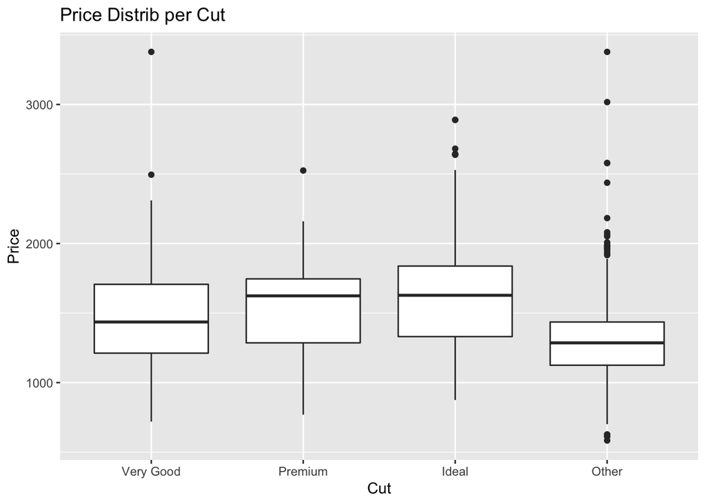

```r
ggplot(data = diamonds_cut_reduced, aes(x = cut, y = price)) +
  geom_boxplot() +
  labs(title = "Price Distrib per Cut",
       x = "Cut",
       y = "Price")
```

5. Calculate the number of observations along with the mean and standard deviation of price for each level of cut.

```r
diamonds_cut_reduced %>%
  group_by(cut) %>%
  summarise(count = n(),
            price_mean = mean(price),
            price_std_dev = sd(price)
            )
```

```
## # A tibble: 4 × 4
##   cut       count price_mean price_std_dev
##   <ord>     <int>      <dbl>         <dbl>
## 1 Very Good   332      1489.          339.
## 2 Premium     277      1532.          304.
## 3 Ideal       388      1609.          368.
## 4 Other       261      1341.          365.
```

The cut group, Very Good, in the dataset has 332 observations, a price mean of 1488.66 dollars and a price standard deviation of 339.36 dollars. The cut group, Premium, in the dataset has 277 observations, a price mean of 1531.78 dollars and a price standard deviation of 304.14 dollars. The cut group, Ideal, in the dataset has 388 observations, a price mean of 1608.67 dollars and a price standard deviation of 368.34 dollars. The cut group, Other, in the dataset has 261 combined observations, a price mean of 1340.64 dollars and a price standard deviation of 364.52 dollars.

6. Based on the plots and summary statistics from the previous exercises , does there appear to be a relationship between the cut and price for diamonds that are 0.5 carats? Briefly explain your reasoning.

Based on the plots and summary statistics from previous exercises, I do not think there appears to be a direct correlation or relationship between with cut and price of diamonds of 0.5 carats. From the box plot in Exercise 4, there does not seem a great difference in variation where each category has around the same median across all cuts. Furthermore, the means from Exercise 5 are not far from each other with the less than one standard deviations within each other meaning that there is no clear correlation or relationship between cut and price.

### Analysis of Variance

7. When using ANOVA to compare means across groups, we make the following assumptions (note how similar they are to the assumptions for regression):

Normality: The distribution of the response, y, is approximately normal within each category of the predictor, x - in the ith category, the y’s follow a N(μi,σ2) distribution.

Independence: All observations are independent from one another, i.e. one observation does not affect another.

Constant Variance: The distribution of the response within each category of predictor, x has a common variance, σ2.

Are the assumptions for ANOVA satisfied? Comment on each assumption, including an explanation for your reasoning and any summary statistics and/or plots used to make the conclusion.

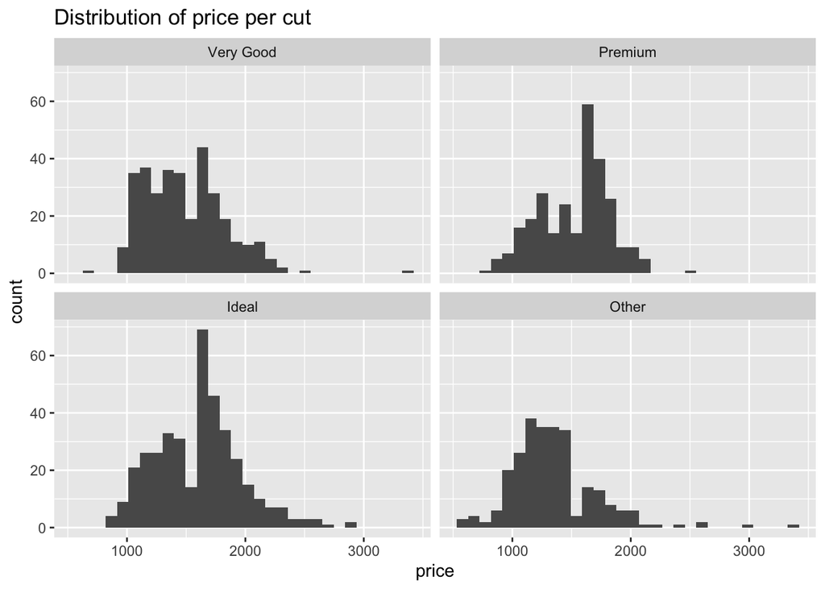

```r
ggplot(data = diamonds_cut_reduced, aes(x = price)) +
  geom_histogram() +
  facet_wrap(~cut) +
  labs(title = "Distribution of price per cut")
```

8. Display the ANOVA table used to examine the relationship between cut and price for diamonds that are 0.5 carats.

```r
price_model <- lm(price ~ cut, data = diamonds_cut_reduced)
anova(price_model) %>%
  kable(format = "markdown", digits = 3)
```

|  | Df | Sum Sq | Mean Sq | F value | Pr(>F) |
| --- | --- | --- | --- | --- | --- |
| cut | 3 | 11507056 | 3835685.3 | 31.916 | 0 |
| Residuals | 1254 | 150706506 | 120180.6 | NA | NA |

9. Use the ANOVA table from the previous question to calculate the sample variance of price. Show the code / formula used to calculate the sample variance.

When thinking about calculating the sample variance of the price, I would want to calculate the total variation which can be calculated from class:
$$s_y^2 = \frac{SST}{DFT} = \frac{SSB + SSR}{n - 1} = \frac{11507056 + 150706506}{1258 - 1} = 129048.18$$

10. What is σ̂ 2, the estimated variance of price within each level of cut. σ̂2 also known as MSW, the estimated variance of the price within each level of cut is:
    $$MSW = \frac{SSW}{DFW} = \frac{SSW}{n - K} = \frac{150706506}{1258 - 4} = 120180.627$$
11. State the null and alternative hypotheses for the test conducted using the ANOVA table in Exercise 8. State the hypotheses using both statistical notation and words in the context of the data.

Statistical Notation:
$$H_{0}: μ_{price,verygood} = μ_{price, premium} = μ_{price, ideal} = μ_{price, other}$$
Ha: At least one of the price means for each cut selection are not equal to the others.

Words:

Null Hypothesis: The mean price for each different cut of diamond that has a carat of 0.5 is equal to each other. In other words, mean price is about the same across all cuts where cut is not a factor in determining mean price.

Alternative Hypothesis: The mean price for at least one cut category out of the four that have a carat of 0.5 is not equal to the others. As long as one mean price is different from the others, then the alternative hypothesis is true which is attempting to imply that cut of diamond does play a factor in price for diamonds.

12. What is your conclusion for the test specified in the previous question? State the conclusion in the context of the data.

We can conclude that since the p-value is approximately 0, we can reject the null hypothesis that the mean prices among each cut groups are equal to each other. We can say that we are statistically confident that mean prices for each diamond are not all equal to each other. The test assumed that the mean price groups were all equal and gave the probability of observing our dataset for diamonds with carats = 0.5 which is approximately 0. In context of the data, we can say that at least of the cut groups have a statistically different mean price from the others where we cannot say that they all have the same mean price. It looks like conditional probabilities across cuts for mean price differ for at least one cut group of diamonds since they do not all equal each other.

13. Based on the conclusion of the ANOVA test, conduct further statistical analysis to provide more detail about which level(s) is(are) different and by how much. If further statistical analysis is not required, provide a brief explanation why it isn’t based on the conclusion from the ANOVA test.

```r
tidy(price_model, conf.int = TRUE) %>%
  kable(format = "markdown", digits = 3)
```

| term | estimate | std.error | statistic | p.value | conf.low | conf.high |
| --- | --- | --- | --- | --- | --- | --- |
| (Intercept) | 1492.438 | 9.893 | 150.852 | 0 | 1473.028 | 1511.847 |
| cut.L | -82.101 | 20.181 | -4.068 | 0 | -121.694 | -42.508 |
| cut.Q | -155.569 | 19.787 | -7.862 | 0 | -194.387 | -116.750 |
| cut.C | -84.678 | 19.384 | -4.368 | 0 | -122.707 | -46.649 |

```r
ideal_and_other <- diamonds_cut_reduced %>% filter(cut == "Other" | cut == "Ideal")
t.test(ideal_and_other$price ~ ideal_and_other$cut, alternative = "two.sided", conf.level = 0.95)
```

```
##
##  Welch Two Sample t-test
##
## data:  ideal_and_other$price by ideal_and_other$cut
## t = 9.146, df = 561.77, p-value < 2.2e-16
## alternative hypothesis: true difference in means between group Ideal and group Other is not equal to 0
## 95 percent confidence interval:
##  210.4629 325.5848
## sample estimates:
## mean in group Ideal mean in group Other
##            1608.668            1340.644
```

```r
ideal_and_verygood <- diamonds_cut_reduced %>% filter(cut == "Very Good" | cut == "Ideal")
t.test(ideal_and_verygood$price ~ ideal_and_verygood$cut, alternative = "two.sided", conf.level = 0.95)
```

```
##
##  Welch Two Sample t-test
##
## data:  ideal_and_verygood$price by ideal_and_verygood$cut
## t = -4.5469, df = 714.07, p-value = 6.394e-06
## alternative hypothesis: true difference in means between group Very Good and group Ideal is not equal to 0
## 95 percent confidence interval:
##  -171.82144  -68.18831
## sample estimates:
## mean in group Very Good     mean in group Ideal
##                1488.663                1608.668
```

```r
ideal_and_premium <- diamonds_cut_reduced %>% filter(cut == "Premium" | cut == "Ideal")
t.test(ideal_and_premium$price ~ ideal_and_premium$cut, alternative = "two.sided", conf.level = 0.95)
```

```
##
##  Welch Two Sample t-test
##
## data:  ideal_and_premium$price by ideal_and_premium$cut
## t = -2.9408, df = 649.08, p-value = 0.00339
## alternative hypothesis: true difference in means between group Premium and group Ideal is not equal to 0
## 95 percent confidence interval:
##  -128.23308  -25.54963
## sample estimates:
## mean in group Premium   mean in group Ideal
##              1531.776              1608.668
```

```r
premium_and_other <- diamonds_cut_reduced %>% filter(cut == "Other" | cut == "Premium")
t.test(premium_and_other$price ~ premium_and_other$cut, alternative = "two.sided", conf.level = 0.95)
```

```
##
##  Welch Two Sample t-test
##
## data:  premium_and_other$price by premium_and_other$cut
## t = 6.5827, df = 507.33, p-value = 1.155e-10
## alternative hypothesis: true difference in means between group Premium and group Other is not equal to 0
## 95 percent confidence interval:
##  134.0881 248.1768
## sample estimates:
## mean in group Premium   mean in group Other
##              1531.776              1340.644
```

```r
premium_and_verygood <- diamonds_cut_reduced %>% filter(cut == "Very Good" | cut == "Premium")
t.test(premium_and_verygood$price ~ premium_and_verygood$cut, alternative = "two.sided", conf.level = 0.95)
```

```
##
##  Welch Two Sample t-test
##
## data:  premium_and_verygood$price by premium_and_verygood$cut
## t = -1.6523, df = 603.88, p-value = 0.09899
## alternative hypothesis: true difference in means between group Very Good and group Premium is not equal to 0
## 95 percent confidence interval:
##  -94.357312   8.130267
## sample estimates:
## mean in group Very Good   mean in group Premium
##                1488.663                1531.776
```

```r
verygood_and_other <- diamonds_cut_reduced %>% filter(cut == "Very Good" | cut == "Other")
t.test(verygood_and_other$price ~ verygood_and_other$cut, alternative = "two.sided", conf.level = 0.95)
```

```
##
##  Welch Two Sample t-test
##
## data:  verygood_and_other$price by verygood_and_other$cut
## t = 5.0592, df = 538.6, p-value = 5.784e-07
## alternative hypothesis: true difference in means between group Very Good and group Other is not equal to 0
## 95 percent confidence interval:
##   90.54646 205.49148
## sample estimates:
## mean in group Very Good     mean in group Other
##                1488.663                1340.644
```